# Time-series forecasting of Covid-19 cases

Biaka Imeah

01/04/2021

# Project Overview

The goal of this project is to identify the nature of the pandemic and forecast its progression in Canada

# About Dataset

# Get packages

```r
library(dplyr)
```

```r
library(tidyr)
library(knitr)   # general purpose tool for dynamic report generation using R
library(ggplot2)
library(prophet)
```

# Get data

```r
data  <- read.csv( file = 'covid19_timeseries.csv')

# Show the first five rows of the data

head(data)
```

```
##   Province.State      Country.Region       Lat      Long      Dates
## 1                        Afghanistan  33.93911  67.70995 2020-01-22
## 2                            Albania  41.15330  20.16830 2020-01-22
## 3                            Algeria  28.03390   1.65960 2020-01-22
## 4                            Andorra  42.50630   1.52180 2020-01-22
## 5                             Angola -11.20270  17.87390 2020-01-22
## 6                Antigua and Barbuda  17.06080 -61.79640 2020-01-22
##   Confirmed.Cases Death.Cases Recovered.Cases
## 1               0           0               0
## 2               0           0               0
## 3               0           0               0
## 4               0           0               0
## 5               0           0               0
## 6               0           0               0
```

## Structure of data

```r
# Get information about the data and the variables

str(data)
```

```
## 'data.frame':    75576 obs. of  8 variables:
##  $ Province.State : chr  "" "" "" "" ...
##  $ Country.Region : chr  "Afghanistan" "Albania" "Algeria" "Andorra" ...
##  $ Lat            : num  33.9 41.2 28 42.5 -11.2 ...
##  $ Long           : num  67.71 20.17 1.66 1.52 17.87 ...
##  $ Dates          : chr  "2020-01-22" "2020-01-22" "2020-01-22" "2020-01-22" ...
##  $ Confirmed.Cases: int  0 0 0 0 0 0 0 0 0 0 ...
##  $ Death.Cases    : int  0 0 0 0 0 0 0 0 0 0 ...
##  $ Recovered.Cases: num  0 0 0 0 0 0 0 0 0 0 ...
```

### Transform the date variable from “character” to “date” type

Specifying that the date variable is a date - makes it easier to work with.

```r
data$Dates <- as.Date(data$Dates)
```

## Create country_level data - Aggregate at country-level

For example, aggregates provincial or state-level data to country-level data

```r
country_data <- data %>% group_by(Dates,Country.Region) %>% summarize( Death.Cases=sum(Death.Cases), Confirmed.Cases=sum(Confirmed.Cases), Recovered.Cases=sum(Recovered.Cases), .groups = "drop")
```

# Extract Canada’s data

Get the for Canada only.

```r
canada <- country_data %>%filter(Country.Region=="Canada")
```

## Summarize Canada’s data

```r
summary(canada)
```

```
##      Dates            Country.Region      Death.Cases      Confirmed.Cases
##  Min.   :2020-01-22   Length:282         Min.   :    0.0   Min.   :     0
##  1st Qu.:2020-04-01   Class :character   1st Qu.:  116.5   1st Qu.:  9991
##  Median :2020-06-10   Mode  :character   Median : 8054.5   Median : 98940
##  Mean   :2020-06-10                      Mean   : 5593.9   Mean   : 83785
##  3rd Qu.:2020-08-19                      3rd Qu.: 9096.5   3rd Qu.:125571
##  Max.   :2020-10-29                      Max.   :10127.0   Max.   :231383
##
##  Recovered.Cases
##  Min.   :      0
##  1st Qu.:   3370
##  Median :  72218
##  Mean   : 451664
##  3rd Qu.: 385433
##  Max.   :8995321
##  NA's   :13
```

## Visualize Canada’s daily confirmed cases

```r
##install.packages("gridExtra")
library("gridExtra")
```

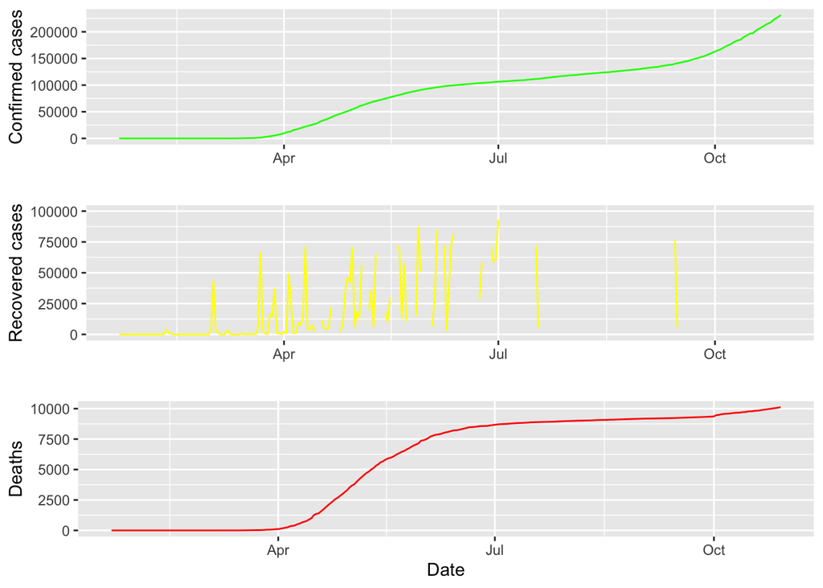

```r
confirmed <- ggplot(canada, aes(x=Dates, y= Confirmed.Cases )) +
  geom_line(color="green") + labs(tittle = "Daily Confirmed COVID-19 cases in Canada", x = " " , y="Confirmed cases")

recovered <- ggplot(canada, aes(x=Dates, y=Recovered.Cases)) +
   geom_line(color="yellow") + labs(tittle = " Daily  recovered cases in Canada", x = " ", y="Recovered cases")+ scale_y_continuous(limits=c(0,100000))

deaths <- ggplot(canada, aes(x=Dates, y=Death.Cases)) +
   geom_line(color="red") + labs(tittle = " Daily COVID-19 deaths in Canada", x="Date", y="Deaths")

grid.arrange(confirmed, recovered, deaths, ncol=1, nrow=3)
```

# Forecasting COVID19 Confirmed cases in Canada - Using Facebook Prophet Library

```r
# Store confirmed cases variable as y
y <- canada$Confirmed.Cases

# Store date variable as dt
ds <- canada$Dates

# Create a dataframe object with these two variables
df <- data.frame(ds, y)
```

## Prophet Library

https://facebook.github.io/prophet/

1. Prophet is utilized in a variety of Facebook apps to generate accurate forecasts for planning and goal-setting.
2. It’s a time series data forecasting process based on an additive model that fits non-linear trends with yearly, weekly, and daily seasonality, as well as holiday impacts.

### Forecasting:

```r
# Call the prophet function to fit the model to the prepared dataframe

model <- prophet(df)
```

```
## Disabling yearly seasonality. Run prophet with yearly.seasonality=TRUE to override this.
```

```
## Disabling daily seasonality. Run prophet with daily.seasonality=TRUE to override this.
```

### Prediction:

1. Predicting cases for the next 30 days

```r
future <- make_future_dataframe(model, periods = 30)
pred <- predict(model, future)
```

### Plot Forecast:

Interactive plot of forecast

```r
dyplot.prophet(model, pred)
```

[interactive chart not shown]

The actual is the black line while predicted values is the blue line. The blue line also shows a confidence interval. On August 1, 2020, there was 118,523 confirmed cases in Canada. The model predicted 117,940

### Forecast Component

On which day of the week is COVID-19 mostly reported?

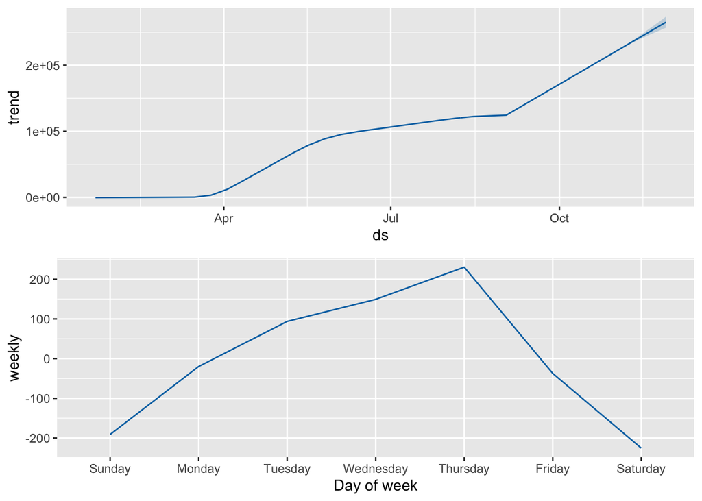

```r
prophet_plot_components(model, pred)
```

### Model Performance

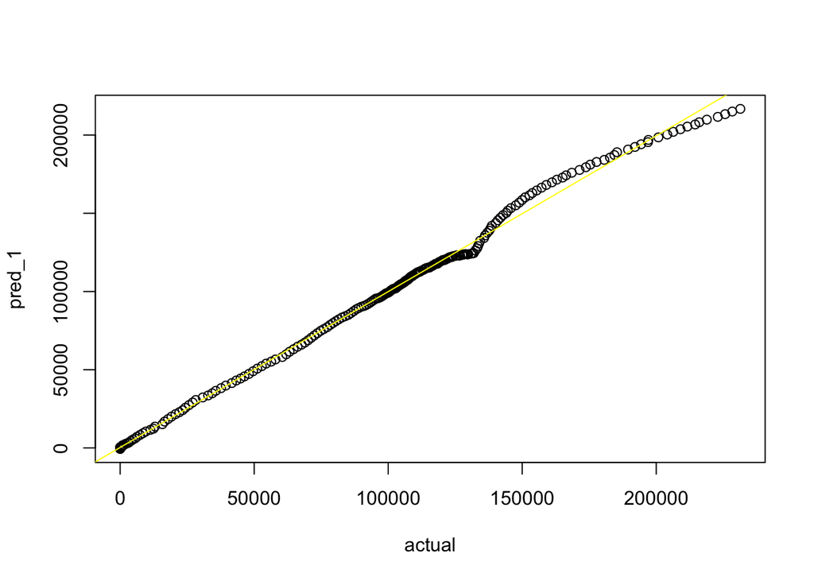

```r
pred_1 <- pred$yhat[1:282]
actual <- model$history$y
plot(actual, pred_1)
abline(lm(pred_1~actual), col = "yellow")
```

```r
summary(lm(pred_1~actual))
```

```
##
## Call:
## lm(formula = pred_1 ~ actual)
##
## Residuals:
##      Min       1Q   Median       3Q      Max
## -14091.4   -683.6   -185.1    552.9   9450.0
##
## Coefficients:
##              Estimate Std. Error t value Pr(>|t|)
## (Intercept) 3.090e+02  3.236e+02   0.955    0.341
## actual      9.963e-01  3.077e-03 323.785   <2e-16 ***
## ---
## Signif. codes:  0 '***' 0.001 '**' 0.01 '*' 0.05 '.' 0.1 ' ' 1
##
## Residual standard error: 3285 on 280 degrees of freedom
## Multiple R-squared:  0.9973, Adjusted R-squared:  0.9973
## F-statistic: 1.048e+05 on 1 and 280 DF,  p-value: < 2.2e-16
```

1. The plot shows the actual versus predicted values. Except for the one kink, the plot appears to be fairly linear i.e. there aren’t a lot of overestimation or underestimation .
2. In a regression model, R-squared (R2) represents the correlation between the actual outcomes and the predicted values by the model. R2 is between 0 and 1. The higher (closer to 1) the R2, the better the model. The R2 of the model used in predicting COVID19 cases in Canada is is 0.9973. It’s really high. This means that 99% of observed variation in confirmed cases can be explain by the model i.e. the model fits the data really well.

# Conclusion

The fitted-model has an R-squared of 0.9973. This implies that te model fits the actual or observed data really well.